# Studio su cause di morte negli USA degli ultimi 15 anni

Prendiamo i dati relativi alle maggiori cause di morte negli USA relative agli ultimi 15 anni. I dati sono presi dal sito del governo americano.  
Il file con i dati è scaricabile qui: https://catalog.data.gov/dataset/age-adjusted-death-rates-for-the-top-10-leading-causes-of-death-united-states-2013

```python
import numpy as np, pandas as pd
import matplotlib.pyplot as plt
```

```python
df = pd.read_csv('D:\\Admin_1\\Download\\NCHS_-_Leading_Causes_of_Death__United_States.csv')
```

Le prime 10 righe di questa tabella sono ad esempio relative al primo anno preso in esame. La prima riga ad esempio ci dice che nel 1999, in Alabama, sono morte 2313 persone a causa di incidenti fortuiti.

```python
df.head(10)
```

|  | Year | 113 Cause Name | Cause Name | State | Deaths | Age-adjusted Death Rate |
| --- | --- | --- | --- | --- | --- | --- |
| 0 | 1999 | Accidents (unintentional injuries) (V01-X59,Y8... | Unintentional Injuries | Alabama | 2313.0 | 52.2 |
| 1 | 1999 | Accidents (unintentional injuries) (V01-X59,Y8... | Unintentional Injuries | Alaska | 294.0 | 55.9 |
| 2 | 1999 | Accidents (unintentional injuries) (V01-X59,Y8... | Unintentional Injuries | Arizona | 2214.0 | 44.8 |
| 3 | 1999 | Accidents (unintentional injuries) (V01-X59,Y8... | Unintentional Injuries | Arkansas | 1287.0 | 47.6 |
| 4 | 1999 | Accidents (unintentional injuries) (V01-X59,Y8... | Unintentional Injuries | California | 9198.0 | 28.7 |
| 5 | 1999 | Accidents (unintentional injuries) (V01-X59,Y8... | Unintentional Injuries | Colorado | 1519.0 | 39.0 |
| 6 | 1999 | Accidents (unintentional injuries) (V01-X59,Y8... | Unintentional Injuries | Connecticut | 1034.0 | 29.3 |
| 7 | 1999 | Accidents (unintentional injuries) (V01-X59,Y8... | Unintentional Injuries | Delaware | 267.0 | 35.3 |
| 8 | 1999 | Accidents (unintentional injuries) (V01-X59,Y8... | Unintentional Injuries | District of Columbia | 161.0 | 28.4 |
| 9 | 1999 | Accidents (unintentional injuries) (V01-X59,Y8... | Unintentional Injuries | Florida | 5961.0 | 35.7 |

Cerchiamo ora di strutturare i dati in maniera da avere piu' informazioni possibili.  
A tal fine modifichiamo il database originale in maniera tale da sintetizzarlo in questo modo:  
per ogni anno e per ogni causa di morte vediamo qual è la **somma dei decessi fra tutti gli Stati USA**

```python
df2 = df['Deaths'].groupby([df['Year'],df['Cause Name']]).sum()
df2unstack = df2.unstack()
df2unstack
```

| Cause Name Year | All Causes | Alzheimer's disease | CLRD | Cancer | Chronic liver disease and cirrhosis | Diabetes | Diseases of Heart | Essential hypertension and hypertensive renal disease | Homicide | Influenza and pneumonia | Kidney Disease | Parkinson's disease | Pneumonitis due to solids and liquids | Septicemia | Stroke | Suicide | Unintentional Injuries |
| --- | --- | --- | --- | --- | --- | --- | --- | --- | --- | --- | --- | --- | --- | --- | --- | --- | --- |
| 1999 | 4782798.0 | 89072.0 | 248362.0 | 1099676.0 | 52518.0 | 136798.0 | 1450384.0 | 33931.0 | 33778.0 | 127460.0 | 71050.0 | 29186.0 | 30536.0 | 61360.0 | 334732.0 | 58398.0 | 195720.0 |
| 2000 | 4806702.0 | 99116.0 | 244018.0 | 1106182.0 | 53104.0 | 138602.0 | 1421520.0 | 36146.0 | 33530.0 | 130626.0 | 74502.0 | 31364.0 | 33272.0 | 62448.0 | 335322.0 | 58700.0 | 195800.0 |
| 2001 | 4832850.0 | 107704.0 | 246026.0 | 1107536.0 | 54070.0 | 142744.0 | 1400284.0 | 38494.0 | 40607.0 | 124068.0 | 78960.0 | 33088.0 | 34602.0 | 64476.0 | 327076.0 | 61244.0 | 203074.0 |
| 2002 | 4886774.0 | 117732.0 | 249632.0 | 1114542.0 | 54514.0 | 146498.0 | 1393894.0 | 40513.0 | 35252.0 | 131362.0 | 81948.0 | 33918.0 | 35186.0 | 67730.0 | 325344.0 | 63310.0 | 213484.0 |
| 2003 | 4896576.0 | 126914.0 | 252764.0 | 1113804.0 | 55006.0 | 148438.0 | 1370178.0 | 43880.0 | 35464.0 | 130326.0 | 84906.0 | 35994.0 | 34670.0 | 68138.0 | 315378.0 | 62968.0 | 218554.0 |
| 2004 | 4795230.0 | 131930.0 | 243974.0 | 1107776.0 | 54026.0 | 146276.0 | 1304972.0 | 46152.0 | 34714.0 | 119328.0 | 84960.0 | 35978.0 | 33560.0 | 66746.0 | 300148.0 | 64878.0 | 224024.0 |
| 2005 | 4896034.0 | 143198.0 | 261866.0 | 1118624.0 | 55060.0 | 150238.0 | 1304182.0 | 49804.0 | 36248.0 | 126002.0 | 87802.0 | 39088.0 | 34558.0 | 68272.0 | 287158.0 | 65274.0 | 235618.0 |
| 2006 | 4852528.0 | 144864.0 | 249166.0 | 1119776.0 | 55110.0 | 144898.0 | 1263272.0 | 47710.0 | 37137.0 | 112652.0 | 90688.0 | 39132.0 | 33774.0 | 68468.0 | 274238.0 | 66600.0 | 243198.0 |
| 2007 | 4847424.0 | 149264.0 | 255848.0 | 1125750.0 | 58330.0 | 142764.0 | 1232134.0 | 47930.0 | 36722.0 | 105434.0 | 92896.0 | 40116.0 | 33976.0 | 69656.0 | 271904.0 | 69196.0 | 247412.0 |
| 2008 | 4943968.0 | 164870.0 | 282180.0 | 1130938.0 | 59926.0 | 141106.0 | 1233656.0 | 51484.0 | 35649.0 | 112568.0 | 96474.0 | 40966.0 | 33216.0 | 71854.0 | 268296.0 | 72070.0 | 243804.0 |
| 2009 | 4874326.0 | 158006.0 | 274706.0 | 1135256.0 | 61116.0 | 137410.0 | 1198826.0 | 51468.0 | 33590.0 | 107384.0 | 97870.0 | 41130.0 | 31896.0 | 71278.0 | 257684.0 | 73818.0 | 236042.0 |
| 2010 | 4936870.0 | 166988.0 | 276160.0 | 1149486.0 | 63806.0 | 138142.0 | 1195378.0 | 53268.0 | 32501.0 | 100194.0 | 100952.0 | 44064.0 | 34022.0 | 69624.0 | 258952.0 | 76728.0 | 241718.0 |
| 2011 | 5030916.0 | 169948.0 | 285886.0 | 1153382.0 | 67284.0 | 147662.0 | 1193154.0 | 55706.0 | 32468.0 | 107652.0 | 91182.0 | 46222.0 | 36381.0 | 71496.0 | 257864.0 | 79036.0 | 252876.0 |
| 2012 | 5086558.0 | 167274.0 | 286978.0 | 1165246.0 | 69958.0 | 147864.0 | 1199422.0 | 58230.0 | 33367.0 | 101272.0 | 91244.0 | 47636.0 | 35794.0 | 71684.0 | 257092.0 | 81200.0 | 255584.0 |
| 2013 | 5193986.0 | 169534.0 | 298410.0 | 1169762.0 | 72854.0 | 151156.0 | 1222210.0 | 61540.0 | 32242.0 | 113958.0 | 94224.0 | 50392.0 | 37158.0 | 76312.0 | 257956.0 | 82298.0 | 261114.0 |
| 2014 | 5252836.0 | 187082.0 | 294202.0 | 1183400.0 | 76340.0 | 152976.0 | 1228696.0 | 60442.0 | 31744.0 | 110454.0 | 96292.0 | 52300.0 | 37584.0 | 77880.0 | 266206.0 | 85652.0 | 271856.0 |
| 2015 | 5425260.0 | 221122.0 | 310082.0 | 1191860.0 | 80652.0 | 159070.0 | 1267684.0 | 64400.0 | 35586.0 | 114124.0 | 99918.0 | 55944.0 | 39606.0 | 81546.0 | 280646.0 | 88386.0 | 293142.0 |

Vediamo quali sono tutte le cause di morte che compaiono nel database

```python
for elem in df2.index.levels[1]:
    print(elem)
```

```
All Causes
Alzheimer's disease
CLRD
Cancer
Chronic liver disease and cirrhosis
Diabetes
Diseases of Heart
Essential hypertension and hypertensive renal disease
Homicide
Influenza and pneumonia
Kidney Disease
Parkinson's disease
Pneumonitis due to solids and liquids
Septicemia
Stroke
Suicide
Unintentional Injuries
```

Ordiniamo il database in modo da visualizzare quali sono nell'ultimo anno preso in considerazione, cioe' l'anno 2015, le cause di morte piu' significative in ordine decrescente.

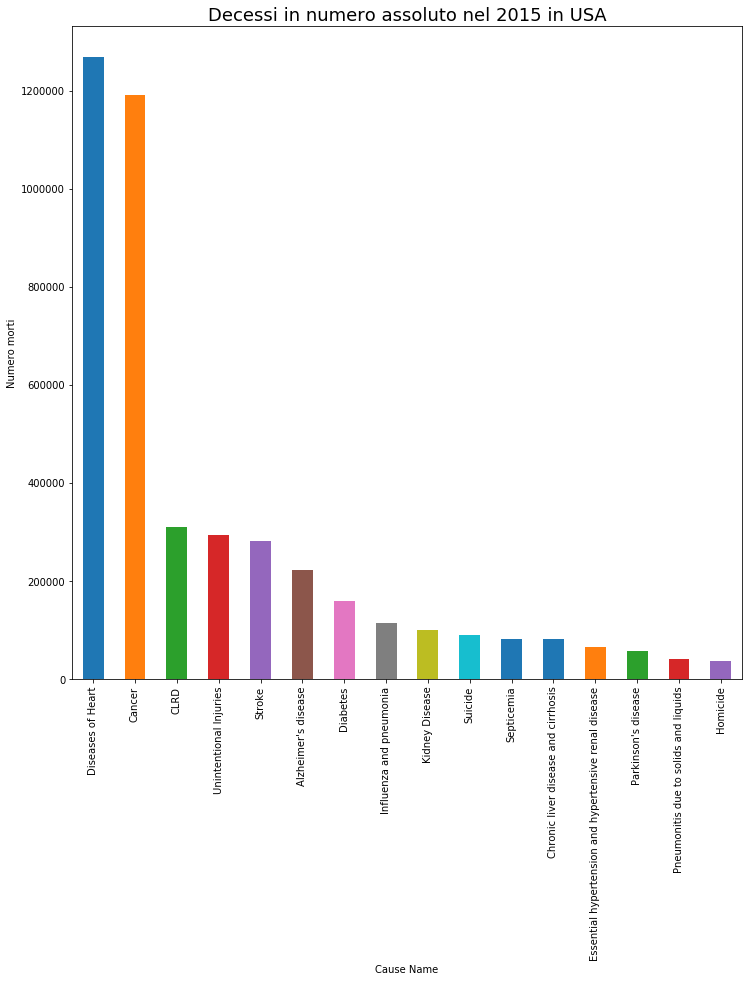

```python
Decessi_2015 = df2unstack.sort_values(by=2015, axis=1, ascending = False).iloc[:,1:]
plt.figure(figsize=(12,12))
plt.title('Decessi in numero assoluto nel 2015 in USA', fontsize=18)
plt.ylabel('Numero morti')
Decessi_2015.loc[2015].plot.bar();
```

Il grafico di sopra ci mostra quindi che le prime tre cause di morte in USA nel 2015 sono:  
1) Malattie legate al cuore  
2) Cancro  
3) Malattie legate all'apparato respiratorio (Chronic Lower Respiratory Disease)

## Quello che pero' noi vogliamo analizzare, non è tanto una fotografia dell'anno 2015, ma capire come si sono evolute queste cause di morte dal 1999 al 2015, per capire se ci sono dei trend evidenti in corso.

Come possiamo vedere nel grafico di sotto infatti, anche se le malattie legate al cuore sono la causa maggiore di decessi, nel corso degli ultimi 15 anni, i decessi legati al cuore sono diminuiti. Il valore assoluto del 2015 quindi ci da poche informazioni. Cio' che va monitorato è come cambia un determinato valore nel corso del tempo. Il grafico sotto ci dice che molto probabilmente si stanno facendo passi avanti nella cura e/o prevenzione delle malattie legate al cuore. Vedremo pero' che un discorso esattamente opposto vale per altre cause di morte

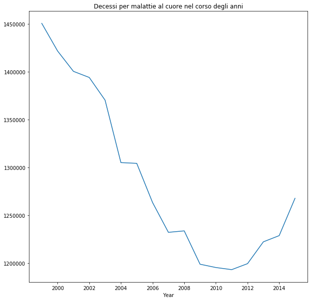

```python
plt.figure(figsize=(10,10))
plt.title('Decessi per malattie al cuore nel corso degli anni')
df2unstack['Diseases of Heart'].plot();
```

La tabella di sotto mostra la differenza di decessi tra un anno e quello precedente, per ogni singola causa di morte

```python
delta_values = {}
for elem in df2.index.levels[1]:
    singlecause = df2.loc[:, elem]
    delta_annuo = singlecause.diff()[1:]
    delta_values[elem] = delta_annuo

delta_values = pd.DataFrame(delta_values)
delta_values
```

| Year | All Causes | Alzheimer's disease | CLRD | Cancer | Chronic liver disease and cirrhosis | Diabetes | Diseases of Heart | Essential hypertension and hypertensive renal disease | Homicide | Influenza and pneumonia | Kidney Disease | Parkinson's disease | Pneumonitis due to solids and liquids | Septicemia | Stroke | Suicide | Unintentional Injuries |
| --- | --- | --- | --- | --- | --- | --- | --- | --- | --- | --- | --- | --- | --- | --- | --- | --- | --- |
| 2000 | 23904.0 | 10044.0 | -4344.0 | 6506.0 | 586.0 | 1804.0 | -28864.0 | 2215.0 | -248.0 | 3166.0 | 3452.0 | 2178.0 | 2736.0 | 1088.0 | 590.0 | 302.0 | 80.0 |
| 2001 | 26148.0 | 8588.0 | 2008.0 | 1354.0 | 966.0 | 4142.0 | -21236.0 | 2348.0 | 7077.0 | -6558.0 | 4458.0 | 1724.0 | 1330.0 | 2028.0 | -8246.0 | 2544.0 | 7274.0 |
| 2002 | 53924.0 | 10028.0 | 3606.0 | 7006.0 | 444.0 | 3754.0 | -6390.0 | 2019.0 | -5355.0 | 7294.0 | 2988.0 | 830.0 | 584.0 | 3254.0 | -1732.0 | 2066.0 | 10410.0 |
| 2003 | 9802.0 | 9182.0 | 3132.0 | -738.0 | 492.0 | 1940.0 | -23716.0 | 3367.0 | 212.0 | -1036.0 | 2958.0 | 2076.0 | -516.0 | 408.0 | -9966.0 | -342.0 | 5070.0 |
| 2004 | -101346.0 | 5016.0 | -8790.0 | -6028.0 | -980.0 | -2162.0 | -65206.0 | 2272.0 | -750.0 | -10998.0 | 54.0 | -16.0 | -1110.0 | -1392.0 | -15230.0 | 1910.0 | 5470.0 |
| 2005 | 100804.0 | 11268.0 | 17892.0 | 10848.0 | 1034.0 | 3962.0 | -790.0 | 3652.0 | 1534.0 | 6674.0 | 2842.0 | 3110.0 | 998.0 | 1526.0 | -12990.0 | 396.0 | 11594.0 |
| 2006 | -43506.0 | 1666.0 | -12700.0 | 1152.0 | 50.0 | -5340.0 | -40910.0 | -2094.0 | 889.0 | -13350.0 | 2886.0 | 44.0 | -784.0 | 196.0 | -12920.0 | 1326.0 | 7580.0 |
| 2007 | -5104.0 | 4400.0 | 6682.0 | 5974.0 | 3220.0 | -2134.0 | -31138.0 | 220.0 | -415.0 | -7218.0 | 2208.0 | 984.0 | 202.0 | 1188.0 | -2334.0 | 2596.0 | 4214.0 |
| 2008 | 96544.0 | 15606.0 | 26332.0 | 5188.0 | 1596.0 | -1658.0 | 1522.0 | 3554.0 | -1073.0 | 7134.0 | 3578.0 | 850.0 | -760.0 | 2198.0 | -3608.0 | 2874.0 | -3608.0 |
| 2009 | -69642.0 | -6864.0 | -7474.0 | 4318.0 | 1190.0 | -3696.0 | -34830.0 | -16.0 | -2059.0 | -5184.0 | 1396.0 | 164.0 | -1320.0 | -576.0 | -10612.0 | 1748.0 | -7762.0 |
| 2010 | 62544.0 | 8982.0 | 1454.0 | 14230.0 | 2690.0 | 732.0 | -3448.0 | 1800.0 | -1089.0 | -7190.0 | 3082.0 | 2934.0 | 2126.0 | -1654.0 | 1268.0 | 2910.0 | 5676.0 |
| 2011 | 94046.0 | 2960.0 | 9726.0 | 3896.0 | 3478.0 | 9520.0 | -2224.0 | 2438.0 | -33.0 | 7458.0 | -9770.0 | 2158.0 | 2359.0 | 1872.0 | -1088.0 | 2308.0 | 11158.0 |
| 2012 | 55642.0 | -2674.0 | 1092.0 | 11864.0 | 2674.0 | 202.0 | 6268.0 | 2524.0 | 899.0 | -6380.0 | 62.0 | 1414.0 | -587.0 | 188.0 | -772.0 | 2164.0 | 2708.0 |
| 2013 | 107428.0 | 2260.0 | 11432.0 | 4516.0 | 2896.0 | 3292.0 | 22788.0 | 3310.0 | -1125.0 | 12686.0 | 2980.0 | 2756.0 | 1364.0 | 4628.0 | 864.0 | 1098.0 | 5530.0 |
| 2014 | 58850.0 | 17548.0 | -4208.0 | 13638.0 | 3486.0 | 1820.0 | 6486.0 | -1098.0 | -498.0 | -3504.0 | 2068.0 | 1908.0 | 426.0 | 1568.0 | 8250.0 | 3354.0 | 10742.0 |
| 2015 | 172424.0 | 34040.0 | 15880.0 | 8460.0 | 4312.0 | 6094.0 | 38988.0 | 3958.0 | 3842.0 | 3670.0 | 3626.0 | 3644.0 | 2022.0 | 3666.0 | 14440.0 | 2734.0 | 21286.0 |

Cio' che pero' piu' ci interessa è vedere qual è questa differenza cumulativa nel corso degli anni, per ogni causa di morte. Il tutto rispetto ad un anno di riferimento, che ovviamente è l'anno dal quale si inizia l'indagine. In questo caso il 1999.  
Ordiniamo quindi la tabella in ordine decrescente, dalla causa di morte che è piu' cresciuta nel corso degli anni, a quella meno. Per ogni anno e per ogni causa di morte abbiamo quindi qual è la differenza tra il numero di decessi di quell'anno e il numero di decessi del 1999.

```python
diff_cumulata = delta_values.cumsum()
del diff_cumulata['All Causes'] #qui eliminiamo 'All Causes' dalla tabella
diff_cumulata_sorted = diff_cumulata.sort_values(by = 2015, axis = 1, ascending = False)
diff_cumulata_sorted
```

| Year | Alzheimer's disease | Unintentional Injuries | Cancer | CLRD | Essential hypertension and hypertensive renal disease | Suicide | Kidney Disease | Chronic liver disease and cirrhosis | Parkinson's disease | Diabetes | Septicemia | Pneumonitis due to solids and liquids | Homicide | Influenza and pneumonia | Stroke | Diseases of Heart |
| --- | --- | --- | --- | --- | --- | --- | --- | --- | --- | --- | --- | --- | --- | --- | --- | --- |
| 2000 | 10044.0 | 80.0 | 6506.0 | -4344.0 | 2215.0 | 302.0 | 3452.0 | 586.0 | 2178.0 | 1804.0 | 1088.0 | 2736.0 | -248.0 | 3166.0 | 590.0 | -28864.0 |
| 2001 | 18632.0 | 7354.0 | 7860.0 | -2336.0 | 4563.0 | 2846.0 | 7910.0 | 1552.0 | 3902.0 | 5946.0 | 3116.0 | 4066.0 | 6829.0 | -3392.0 | -7656.0 | -50100.0 |
| 2002 | 28660.0 | 17764.0 | 14866.0 | 1270.0 | 6582.0 | 4912.0 | 10898.0 | 1996.0 | 4732.0 | 9700.0 | 6370.0 | 4650.0 | 1474.0 | 3902.0 | -9388.0 | -56490.0 |
| 2003 | 37842.0 | 22834.0 | 14128.0 | 4402.0 | 9949.0 | 4570.0 | 13856.0 | 2488.0 | 6808.0 | 11640.0 | 6778.0 | 4134.0 | 1686.0 | 2866.0 | -19354.0 | -80206.0 |
| 2004 | 42858.0 | 28304.0 | 8100.0 | -4388.0 | 12221.0 | 6480.0 | 13910.0 | 1508.0 | 6792.0 | 9478.0 | 5386.0 | 3024.0 | 936.0 | -8132.0 | -34584.0 | -145412.0 |
| 2005 | 54126.0 | 39898.0 | 18948.0 | 13504.0 | 15873.0 | 6876.0 | 16752.0 | 2542.0 | 9902.0 | 13440.0 | 6912.0 | 4022.0 | 2470.0 | -1458.0 | -47574.0 | -146202.0 |
| 2006 | 55792.0 | 47478.0 | 20100.0 | 804.0 | 13779.0 | 8202.0 | 19638.0 | 2592.0 | 9946.0 | 8100.0 | 7108.0 | 3238.0 | 3359.0 | -14808.0 | -60494.0 | -187112.0 |
| 2007 | 60192.0 | 51692.0 | 26074.0 | 7486.0 | 13999.0 | 10798.0 | 21846.0 | 5812.0 | 10930.0 | 5966.0 | 8296.0 | 3440.0 | 2944.0 | -22026.0 | -62828.0 | -218250.0 |
| 2008 | 75798.0 | 48084.0 | 31262.0 | 33818.0 | 17553.0 | 13672.0 | 25424.0 | 7408.0 | 11780.0 | 4308.0 | 10494.0 | 2680.0 | 1871.0 | -14892.0 | -66436.0 | -216728.0 |
| 2009 | 68934.0 | 40322.0 | 35580.0 | 26344.0 | 17537.0 | 15420.0 | 26820.0 | 8598.0 | 11944.0 | 612.0 | 9918.0 | 1360.0 | -188.0 | -20076.0 | -77048.0 | -251558.0 |
| 2010 | 77916.0 | 45998.0 | 49810.0 | 27798.0 | 19337.0 | 18330.0 | 29902.0 | 11288.0 | 14878.0 | 1344.0 | 8264.0 | 3486.0 | -1277.0 | -27266.0 | -75780.0 | -255006.0 |
| 2011 | 80876.0 | 57156.0 | 53706.0 | 37524.0 | 21775.0 | 20638.0 | 20132.0 | 14766.0 | 17036.0 | 10864.0 | 10136.0 | 5845.0 | -1310.0 | -19808.0 | -76868.0 | -257230.0 |
| 2012 | 78202.0 | 59864.0 | 65570.0 | 38616.0 | 24299.0 | 22802.0 | 20194.0 | 17440.0 | 18450.0 | 11066.0 | 10324.0 | 5258.0 | -411.0 | -26188.0 | -77640.0 | -250962.0 |
| 2013 | 80462.0 | 65394.0 | 70086.0 | 50048.0 | 27609.0 | 23900.0 | 23174.0 | 20336.0 | 21206.0 | 14358.0 | 14952.0 | 6622.0 | -1536.0 | -13502.0 | -76776.0 | -228174.0 |
| 2014 | 98010.0 | 76136.0 | 83724.0 | 45840.0 | 26511.0 | 27254.0 | 25242.0 | 23822.0 | 23114.0 | 16178.0 | 16520.0 | 7048.0 | -2034.0 | -17006.0 | -68526.0 | -221688.0 |
| 2015 | 132050.0 | 97422.0 | 92184.0 | 61720.0 | 30469.0 | 29988.0 | 28868.0 | 28134.0 | 26758.0 | 22272.0 | 20186.0 | 9070.0 | 1808.0 | -13336.0 | -54086.0 | -182700.0 |

La tabella di sopra è particolarmente importante: ci dice che le cause di morte che piu' sono aumentate in valore assoluto negli USA negli ultimi 15 anni sono:  
1) Alzheimer (nel 2015 ci sono 132 mila decessi in piu' rispetto al 1999 riconducibili a questa malattia)  
2) Incidenti fortuiti  
3) Cancro  
L'ultimo step da fare è rapportare questo differenziale assoluto con quello che era il valore assoluto di ogni causa di morte nel 1999. In questo modo troveremo il tasso con il quale una certa causa di morte si è evoluta nel corso del tempo. I valori assoluti del 1999 li abbiamo qui sotto:

```python
initvalue = {}
for elem in df2.index.levels[1][1:]:
    singlecause = df2.loc[:,elem]
    initvalue[elem] = singlecause.loc[1999]
initvalue = pd.Series(initvalue)
init_sorted = initvalue.sort_values(ascending = False)
init_sorted
```

```
Diseases of Heart                                        1450384.0
Cancer                                                   1099676.0
Stroke                                                    334732.0
CLRD                                                      248362.0
Unintentional Injuries                                    195720.0
Diabetes                                                  136798.0
Influenza and pneumonia                                   127460.0
Alzheimer's disease                                        89072.0
Kidney Disease                                             71050.0
Septicemia                                                 61360.0
Suicide                                                    58398.0
Chronic liver disease and cirrhosis                        52518.0
Essential hypertension and hypertensive renal disease      33931.0
Homicide                                                   33778.0
Pneumonitis due to solids and liquids                      30536.0
Parkinson's disease                                        29186.0
dtype: float64
```

Quindi creiamo una tabella dove per ogni causa di morte, vediamo qual è il tasso di incremento cumulativo nel corso degli anni. La differenza tra la seguente tabella e la precedente, è che la tabella di sotto tiene conto dello sviluppo anno dopo anno in termini relativi, dandoci il tasso, mentre quella precedente accumulava l'incremento di ciascuna colonna in termini assoluti, dandoci l'incremento assoluto cumulato di decessi per ogni anno.

```python
evolution = diff_cumulata_sorted / init_sorted
evolution_sorted = evolution.sort_values(by = 2015, axis = 1, ascending = False)
evolution_sorted
```

| Year | Alzheimer's disease | Parkinson's disease | Essential hypertension and hypertensive renal disease | Chronic liver disease and cirrhosis | Suicide | Unintentional Injuries | Kidney Disease | Septicemia | Pneumonitis due to solids and liquids | CLRD | Diabetes | Cancer | Homicide | Influenza and pneumonia | Diseases of Heart | Stroke |
| --- | --- | --- | --- | --- | --- | --- | --- | --- | --- | --- | --- | --- | --- | --- | --- | --- |
| 2000 | 0.112763 | 0.074625 | 0.065280 | 0.011158 | 0.005171 | 0.000409 | 0.048586 | 0.017731 | 0.089599 | -0.017491 | 0.013187 | 0.005916 | -0.007342 | 0.024839 | -0.019901 | 0.001763 |
| 2001 | 0.209179 | 0.133694 | 0.134479 | 0.029552 | 0.048735 | 0.037574 | 0.111330 | 0.050782 | 0.133154 | -0.009406 | 0.043466 | 0.007148 | 0.202173 | -0.026612 | -0.034543 | -0.022872 |
| 2002 | 0.321762 | 0.162133 | 0.193982 | 0.038006 | 0.084112 | 0.090762 | 0.153385 | 0.103814 | 0.152279 | 0.005114 | 0.070907 | 0.013519 | 0.043638 | 0.030614 | -0.038948 | -0.028046 |
| 2003 | 0.424847 | 0.233263 | 0.293213 | 0.047374 | 0.078256 | 0.116667 | 0.195018 | 0.110463 | 0.135381 | 0.017724 | 0.085089 | 0.012847 | 0.049914 | 0.022485 | -0.055300 | -0.057819 |
| 2004 | 0.481161 | 0.232714 | 0.360172 | 0.028714 | 0.110963 | 0.144615 | 0.195778 | 0.087777 | 0.099031 | -0.017668 | 0.069285 | 0.007366 | 0.027710 | -0.063800 | -0.100258 | -0.103318 |
| 2005 | 0.607666 | 0.339272 | 0.467802 | 0.048402 | 0.117744 | 0.203852 | 0.235778 | 0.112647 | 0.131713 | 0.054372 | 0.098247 | 0.017231 | 0.073125 | -0.011439 | -0.100802 | -0.142126 |
| 2006 | 0.626370 | 0.340780 | 0.406089 | 0.049355 | 0.140450 | 0.242581 | 0.276397 | 0.115841 | 0.106039 | 0.003237 | 0.059211 | 0.018278 | 0.099443 | -0.116178 | -0.129009 | -0.180724 |
| 2007 | 0.675768 | 0.374495 | 0.412573 | 0.110667 | 0.184904 | 0.264112 | 0.307474 | 0.135202 | 0.112654 | 0.030141 | 0.043612 | 0.023711 | 0.087157 | -0.172807 | -0.150477 | -0.187696 |
| 2008 | 0.850974 | 0.403618 | 0.517315 | 0.141056 | 0.234118 | 0.245677 | 0.357833 | 0.171023 | 0.087765 | 0.136164 | 0.031492 | 0.028428 | 0.055391 | -0.116837 | -0.149428 | -0.198475 |
| 2009 | 0.773913 | 0.409237 | 0.516843 | 0.163715 | 0.264050 | 0.206019 | 0.377481 | 0.161636 | 0.044538 | 0.106071 | 0.004474 | 0.032355 | -0.005566 | -0.157508 | -0.173442 | -0.230178 |
| 2010 | 0.874753 | 0.509765 | 0.569892 | 0.214936 | 0.313881 | 0.235019 | 0.420859 | 0.134681 | 0.114160 | 0.111925 | 0.009825 | 0.045295 | -0.037806 | -0.213918 | -0.175820 | -0.226390 |
| 2011 | 0.907985 | 0.583705 | 0.641744 | 0.281161 | 0.353403 | 0.292029 | 0.283350 | 0.165189 | 0.191413 | 0.151086 | 0.079416 | 0.048838 | -0.038783 | -0.155406 | -0.177353 | -0.229640 |
| 2012 | 0.877964 | 0.632152 | 0.716130 | 0.332077 | 0.390459 | 0.305866 | 0.284222 | 0.168253 | 0.172190 | 0.155483 | 0.080893 | 0.059627 | -0.012168 | -0.205461 | -0.173031 | -0.231947 |
| 2013 | 0.903337 | 0.726581 | 0.813681 | 0.387220 | 0.409261 | 0.334120 | 0.326165 | 0.243677 | 0.216859 | 0.201512 | 0.104958 | 0.063733 | -0.045473 | -0.105931 | -0.157320 | -0.229366 |
| 2014 | 1.100346 | 0.791955 | 0.781321 | 0.453597 | 0.466694 | 0.389005 | 0.355271 | 0.269231 | 0.230810 | 0.184569 | 0.118262 | 0.076135 | -0.060217 | -0.133422 | -0.152848 | -0.204719 |
| 2015 | 1.482509 | 0.916809 | 0.897969 | 0.535702 | 0.513511 | 0.497762 | 0.406305 | 0.328977 | 0.297026 | 0.248508 | 0.162809 | 0.083828 | 0.053526 | -0.104629 | -0.125967 | -0.161580 |

La tabella di sopra quindi ci mostra le cause di morte che piu' sono cresciute nel corso degli anni, in ordine descrescente da sx verso dx, in termini relativi.  
Nel 2015 il numero dei decessi causati dall'Alzheimer è aumentato del 148% rispetto al 1999.  
Nel 2015 il numero del decessi causati dal Parkinson è aumentato del 91,6% rispetto al 1999.  
E cosi via.  
Andiamo a mettere su un grafico quest'ultima tabella

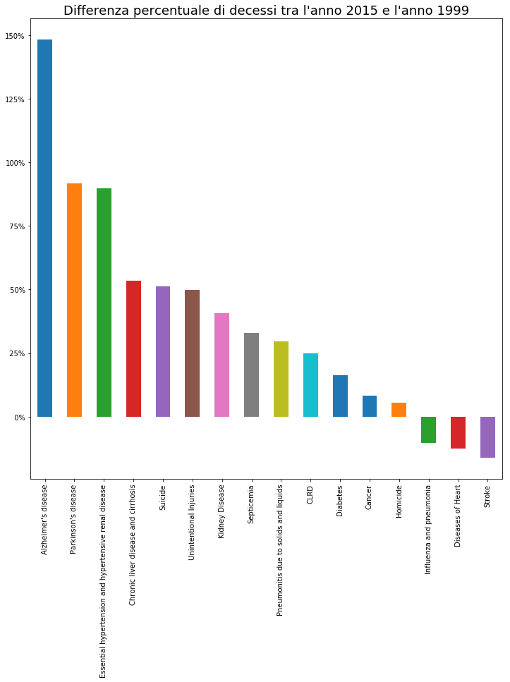

```python
plt.figure(figsize=(12,12))
ax = evolution_sorted.loc[2015].plot.bar()
vals = ax.get_yticks()
plt.title('Differenza percentuale di decessi tra l\'anno 2015 e l\'anno 1999',fontsize=18)
ax.set_yticklabels(['{:3.0f}%'.format(x*100) for x in vals]);
```

Come invece avevamo gia' fatto notare, le malattie del cuore, nonostante sia ancora la maggiore causa di morte nel 2015, causano meno decessi rispetto a 15 anni fa.

### Prima di continuare pero' andiamo a vedere se è aumentato o diminuita la popozione negli USA negli ultimi 15 anni